# IRIS

### Load Packages

```r
packages <- c("hydroGOF", "miscTools", "MASS", "caret", "earth", "pls", "MASS", "plyr", "miscTools", "gridExtra", "ggplot2", "reshape2", "randomForest", "dplyr", "Boruta", "stringr", "ggthemes", "ReporteRs", "stringr", "lubridate", "corrplot", "tibble", "GGally", "e1071", "tensorflow", "keras")
sapply(packages, function(x)require(x, character.only = TRUE, quietly = TRUE))
```

```
    hydroGOF    miscTools         MASS        caret        earth          pls
        TRUE         TRUE         TRUE         TRUE         TRUE         TRUE
        MASS         plyr    miscTools    gridExtra      ggplot2     reshape2
        TRUE         TRUE         TRUE         TRUE         TRUE         TRUE
randomForest        dplyr       Boruta      stringr     ggthemes    ReporteRs
        TRUE         TRUE         TRUE         TRUE         TRUE         TRUE
     stringr    lubridate     corrplot       tibble       GGally        e1071
        TRUE         TRUE         TRUE         TRUE         TRUE         TRUE
  tensorflow        keras
        TRUE         TRUE
```

```r
rm(packages)
```

### Pre-processing

```r
data(iris)
df <- na.omit(iris)
iris <- NULL
rm(iris)
paste("No. of observations:", nrow(df))
```

```
[1] "No. of observations: 150"
```

```r
paste("No. of variables:", ncol(df))
```

```
[1] "No. of variables: 5"
```

```r
summary(df)
```

```
  Sepal.Length    Sepal.Width     Petal.Length    Petal.Width          Species
 Min.   :4.300   Min.   :2.000   Min.   :1.000   Min.   :0.100   setosa    :50
 1st Qu.:5.100   1st Qu.:2.800   1st Qu.:1.600   1st Qu.:0.300   versicolor:50
 Median :5.800   Median :3.000   Median :4.350   Median :1.300   virginica :50
 Mean   :5.843   Mean   :3.057   Mean   :3.758   Mean   :1.199
 3rd Qu.:6.400   3rd Qu.:3.300   3rd Qu.:5.100   3rd Qu.:1.800
 Max.   :7.900   Max.   :4.400   Max.   :6.900   Max.   :2.500
```

```r
str(df)
```

```
'data.frame':   150 obs. of  5 variables:
 $ Sepal.Length: num  5.1 4.9 4.7 4.6 5 5.4 4.6 5 4.4 4.9 ...
 $ Sepal.Width : num  3.5 3 3.2 3.1 3.6 3.9 3.4 3.4 2.9 3.1 ...
 $ Petal.Length: num  1.4 1.4 1.3 1.5 1.4 1.7 1.4 1.5 1.4 1.5 ...
 $ Petal.Width : num  0.2 0.2 0.2 0.2 0.2 0.4 0.3 0.2 0.2 0.1 ...
 $ Species     : Factor w/ 3 levels "setosa","versicolor",..: 1 1 1 1 1 1 1 1 1 1 ...
```

```r
sapply(df, class)
```

```
Sepal.Length  Sepal.Width Petal.Length  Petal.Width      Species
   "numeric"    "numeric"    "numeric"    "numeric"     "factor"
```

```r
sd_data <- sapply(df[,-ncol(df)], sd, na.rm = TRUE)
df[,-ncol(df)] <- df[,which(sd_data != 0)]
output <- "Species"
```

### Feature Selection

```r
set.seed(123)
borutaTrain <- Boruta(Species~., data = df, doTrace = 0, maxRuns = 200, getImp = getImpLegacyRfZ, ntree = 500)
borutaResults <- attStats(borutaTrain)
borutaResults <- borutaResults %>%
    rownames_to_column %>%
    arrange(desc(normHits), desc(medianImp))
borutaResults[which(sapply(borutaResults, class) == "numeric")] <- round(borutaResults[which(sapply(borutaResults, class) == "numeric")], 2)
inputNames <- getSelectedAttributes(borutaTrain, withTentative = FALSE)
df1 <- df[,c(inputNames, output)] %>% na.omit()
colnames(df1)[ncol(df1)] <- "y"
print("Selected Features ordered by Importance")
```

```
[1] "Selected Features ordered by Importance"
```

```r
borutaResults
```

| rowname | meanImp | medianImp | minImp | maxImp | normHits | decision |
| --- | --- | --- | --- | --- | --- | --- |
| Petal.Width | 31.34 | 31.51 | 30.23 | 32.27 | 1 | Confirmed |
| Petal.Length | 30.57 | 30.69 | 29.54 | 31.56 | 1 | Confirmed |
| Sepal.Length | 16.24 | 16.27 | 15.26 | 17.21 | 1 | Confirmed |
| Sepal.Width | 11.32 | 11.20 | 10.08 | 12.34 | 1 | Confirmed |

## Modelling

### SVM

```r
set.seed(100)
index <- createDataPartition(df1$y, p = 0.80, list = FALSE)
trainDF <- df1[index,]
testDF <- df1[-index,]
```

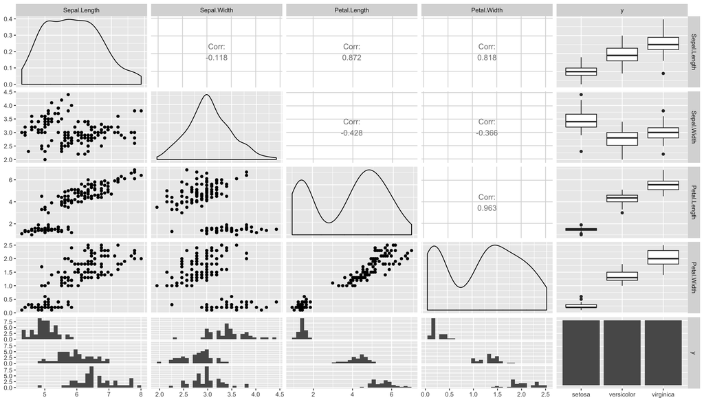

```r
ggpairs(df1)
```

```r
#SVM
svm1 <- svm(y~., data=trainDF,
          method="C-classification", kernal="radial",
          gamma=0.1, cost=1)
summary(svm1)
```

```
Call:
svm(formula = y ~ ., data = trainDF, method = "C-classification", kernal = "radial",
    gamma = 0.1, cost = 1)


Parameters:
   SVM-Type:  C-classification
 SVM-Kernel:  radial
       cost:  1
      gamma:  0.1

Number of Support Vectors:  49

 ( 5 23 21 )


Number of Classes:  3

Levels:
 setosa versicolor virginica
```

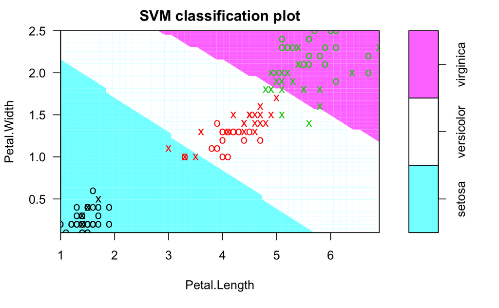

```r
plot(svm1, trainDF, Petal.Width ~ Petal.Length,
          slice=list(Sepal.Width=3, Sepal.Length=4))
```

```r
trainPrediction <- predict(svm1, trainDF)
training <- confusionMatrix(trainDF$y, trainPrediction)
testPrediction <- predict(svm1, testDF)
testing <- confusionMatrix(testDF$y, testPrediction)
training
```

```
Confusion Matrix and Statistics

            Reference
Prediction   setosa versicolor virginica
  setosa         40          0         0
  versicolor      0         39         1
  virginica       0          1        39

Overall Statistics

               Accuracy : 0.9833
                 95% CI : (0.9411, 0.998)
    No Information Rate : 0.3333
    P-Value [Acc > NIR] : < 2.2e-16

                  Kappa : 0.975
 Mcnemar's Test P-Value : NA

Statistics by Class:

                     Class: setosa Class: versicolor Class: virginica
Sensitivity                 1.0000            0.9750           0.9750
Specificity                 1.0000            0.9875           0.9875
Pos Pred Value              1.0000            0.9750           0.9750
Neg Pred Value              1.0000            0.9875           0.9875
Prevalence                  0.3333            0.3333           0.3333
Detection Rate              0.3333            0.3250           0.3250
Detection Prevalence        0.3333            0.3333           0.3333
Balanced Accuracy           1.0000            0.9812           0.9812
```

```r
testing
```

```
Confusion Matrix and Statistics

            Reference
Prediction   setosa versicolor virginica
  setosa         10          0         0
  versicolor      0          9         1
  virginica       0          2         8

Overall Statistics

               Accuracy : 0.9
                 95% CI : (0.7347, 0.9789)
    No Information Rate : 0.3667
    P-Value [Acc > NIR] : 1.888e-09

                  Kappa : 0.85
 Mcnemar's Test P-Value : NA

Statistics by Class:

                     Class: setosa Class: versicolor Class: virginica
Sensitivity                 1.0000            0.8182           0.8889
Specificity                 1.0000            0.9474           0.9048
Pos Pred Value              1.0000            0.9000           0.8000
Neg Pred Value              1.0000            0.9000           0.9500
Prevalence                  0.3333            0.3667           0.3000
Detection Rate              0.3333            0.3000           0.2667
Detection Prevalence        0.3333            0.3333           0.3333
Balanced Accuracy           1.0000            0.8828           0.8968
```

### Tuning SVM using Grid Search

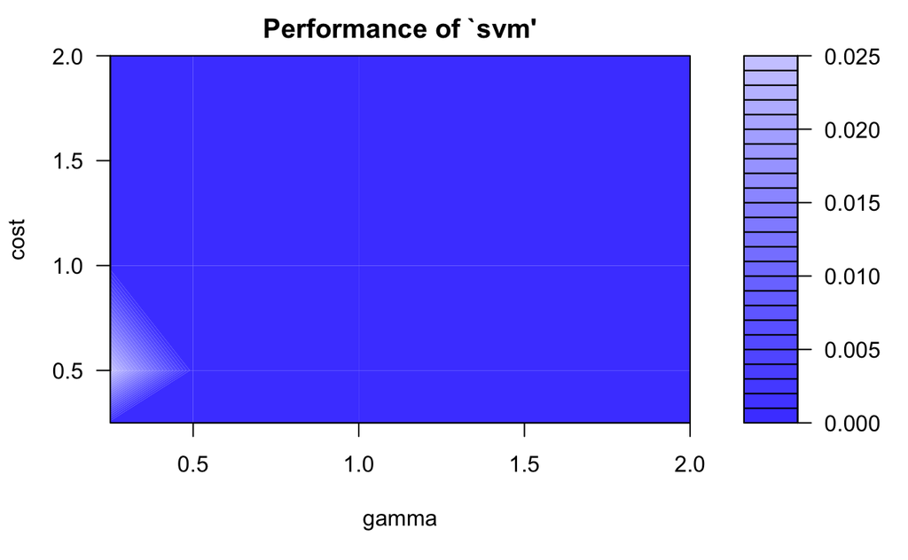

```r
obj <- tune(svm, y~., data = trainDF,
            ranges = list(gamma = 2^(-2:1), cost = 2^(-2:1)),
            tunecontrol = tune.control(sampling = "fix")
)
plot(obj)
```

```r
summary(obj)
```

```
Parameter tuning of ‘svm’:

- sampling method: fixed training/validation set

- best parameters:
```

|  | gamma | cost |
| --- | --- | --- |
|  | 0.25 | 0.25 |

```
- best performance: 0

- Detailed performance results:
```

| gamma | cost | error | dispersion |
| --- | --- | --- | --- |
| 0.25 | 0.25 | 0.000 | NA |
| 0.50 | 0.25 | 0.000 | NA |
| 1.00 | 0.25 | 0.000 | NA |
| 2.00 | 0.25 | 0.000 | NA |
| 0.25 | 0.50 | 0.025 | NA |
| 0.50 | 0.50 | 0.000 | NA |
| 1.00 | 0.50 | 0.000 | NA |
| 2.00 | 0.50 | 0.000 | NA |
| 0.25 | 1.00 | 0.000 | NA |
| 0.50 | 1.00 | 0.000 | NA |

[output cut: 6 more lines]

```
NA
```

```r
svm2 <- svm(y~., data=trainDF,
          method="C-classification", kernal="radial",
          gamma=0.25, cost=0.25)
summary(svm2)
```

```
Call:
svm(formula = y ~ ., data = trainDF, method = "C-classification", kernal = "radial",
    gamma = 0.25, cost = 0.25)


Parameters:
   SVM-Type:  C-classification
 SVM-Kernel:  radial
       cost:  0.25
      gamma:  0.25

Number of Support Vectors:  70

 ( 13 29 28 )


Number of Classes:  3

Levels:
 setosa versicolor virginica
```

```r
trainPredictionTuned <- predict(svm2, trainDF)
trainingTuned <- confusionMatrix(trainDF$y, trainPredictionTuned)
testPredictionTuned <- predict(svm2, testDF)
testingTuned <- confusionMatrix(testDF$y, testPredictionTuned)
trainingTuned
```

```
Confusion Matrix and Statistics

            Reference
Prediction   setosa versicolor virginica
  setosa         40          0         0
  versicolor      0         39         1
  virginica       0          2        38

Overall Statistics

               Accuracy : 0.975
                 95% CI : (0.9287, 0.9948)
    No Information Rate : 0.3417
    P-Value [Acc > NIR] : < 2.2e-16

                  Kappa : 0.9625
 Mcnemar's Test P-Value : NA

Statistics by Class:

                     Class: setosa Class: versicolor Class: virginica
Sensitivity                 1.0000            0.9512           0.9744
Specificity                 1.0000            0.9873           0.9753
Pos Pred Value              1.0000            0.9750           0.9500
Neg Pred Value              1.0000            0.9750           0.9875
Prevalence                  0.3333            0.3417           0.3250
Detection Rate              0.3333            0.3250           0.3167
Detection Prevalence        0.3333            0.3333           0.3333
Balanced Accuracy           1.0000            0.9693           0.9748
```

```r
testingTuned
```

```
Confusion Matrix and Statistics

            Reference
Prediction   setosa versicolor virginica
  setosa         10          0         0
  versicolor      0         10         0
  virginica       0          3         7

Overall Statistics

               Accuracy : 0.9
                 95% CI : (0.7347, 0.9789)
    No Information Rate : 0.4333
    P-Value [Acc > NIR] : 1.255e-07

                  Kappa : 0.85
 Mcnemar's Test P-Value : NA

Statistics by Class:

                     Class: setosa Class: versicolor Class: virginica
Sensitivity                 1.0000            0.7692           1.0000
Specificity                 1.0000            1.0000           0.8696
Pos Pred Value              1.0000            1.0000           0.7000
Neg Pred Value              1.0000            0.8500           1.0000
Prevalence                  0.3333            0.4333           0.2333
Detection Rate              0.3333            0.3333           0.2333
Detection Prevalence        0.3333            0.3333           0.3333
Balanced Accuracy           1.0000            0.8846           0.9348
```

### randomForest

```r
rf <- randomForest(y~., data = trainDF, maxnodes = 3, mtry = 4)
trainingRF <- predict(rf, trainDF)
confusionMatrix(trainingRF, trainDF$y)
```

```
Confusion Matrix and Statistics

            Reference
Prediction   setosa versicolor virginica
  setosa         40          0         0
  versicolor      0         38         0
  virginica       0          2        40

Overall Statistics

               Accuracy : 0.9833
                 95% CI : (0.9411, 0.998)
    No Information Rate : 0.3333
    P-Value [Acc > NIR] : < 2.2e-16

                  Kappa : 0.975
 Mcnemar's Test P-Value : NA

Statistics by Class:

                     Class: setosa Class: versicolor Class: virginica
Sensitivity                 1.0000            0.9500           1.0000
Specificity                 1.0000            1.0000           0.9750
Pos Pred Value              1.0000            1.0000           0.9524
Neg Pred Value              1.0000            0.9756           1.0000
Prevalence                  0.3333            0.3333           0.3333
Detection Rate              0.3333            0.3167           0.3333
Detection Prevalence        0.3333            0.3167           0.3500
Balanced Accuracy           1.0000            0.9750           0.9875
```

```r
testingRF <- predict(rf, testDF)
confusionMatrix(testingRF, testDF$y)
```

```
Confusion Matrix and Statistics

            Reference
Prediction   setosa versicolor virginica
  setosa         10          0         0
  versicolor      0          7         1
  virginica       0          3         9

Overall Statistics

               Accuracy : 0.8667
                 95% CI : (0.6928, 0.9624)
    No Information Rate : 0.3333
    P-Value [Acc > NIR] : 2.296e-09

                  Kappa : 0.8
 Mcnemar's Test P-Value : NA

Statistics by Class:

                     Class: setosa Class: versicolor Class: virginica
Sensitivity                 1.0000            0.7000           0.9000
Specificity                 1.0000            0.9500           0.8500
Pos Pred Value              1.0000            0.8750           0.7500
Neg Pred Value              1.0000            0.8636           0.9444
Prevalence                  0.3333            0.3333           0.3333
Detection Rate              0.3333            0.2333           0.3000
Detection Prevalence        0.3333            0.2667           0.4000
Balanced Accuracy           1.0000            0.8250           0.8750
```

### Linear Discriminant Analysis

Our last model will be the model to explain which Ronald Fisher originally used the Iris dataset. More information about this algorithm can be obtained here.

Linear Discriminant Analysis model is generally used for small data sets which would otherwise suffer from small sample bias in other models. Other classes of models might not be able to pick the trends in the data correctly, so for smaller datasets, a probability based classifier such as bayesian classifiers and lda are more suitable

Linear Discriminant Analysis (LDA) is also most commonly used as dimensionality reduction technique in the pre-processing step for pattern-classification and machine learning applications. The goal is to project a dataset onto a lower-dimensional space with good class-separability in order avoid overfitting (“curse of dimensionality”) and also reduce computational costs. A good discussion of this (although in Python) can be found here

```r
set.seed(100)
LDA <- train(trainDF[,-ncol(trainDF)],y = trainDF$y, method = "lda", metric = "Accuracy")
```

[output not shown]